# PRÁCTICA: VISUALIZACIÓN EN SEABORN

- Integrantes:
- Jorge Emiliano Pomar A01709338
- Francisco Couttolenc A01754959

## 1. (20 pts) Carga este archivoLinks to an external site. de salarios a un dataframe, despliega la estadística descriptiva básica y realiza:

```python
import pandas as pd
import seaborn as sns
from matplotlib import pyplot as plt
```

```python
df = pd.read_csv('HRDataset_v14.csv')
df.head(10)
```

|  | Employee_Name | EmpID | MarriedID | MaritalStatusID | GenderID | EmpStatusID | DeptID | PerfScoreID | FromDiversityJobFairID | Salary | ... | ManagerName | ManagerID | RecruitmentSource | PerformanceScore | EngagementSurvey | EmpSatisfaction | SpecialProjectsCount | LastPerformanceReview_Date | DaysLateLast30 | Absences |
| --- | --- | --- | --- | --- | --- | --- | --- | --- | --- | --- | --- | --- | --- | --- | --- | --- | --- | --- | --- | --- | --- |
| 0 | Adinolfi, Wilson K | 10026 | 0 | 0 | 1 | 1 | 5 | 4 | 0 | 62506 | ... | Michael Albert | 22.0 | LinkedIn | Exceeds | 4.60 | 5 | 0 | 1/17/2019 | 0 | 1 |
| 1 | Ait Sidi, Karthikeyan | 10084 | 1 | 1 | 1 | 5 | 3 | 3 | 0 | 104437 | ... | Simon Roup | 4.0 | Indeed | Fully Meets | 4.96 | 3 | 6 | 2/24/2016 | 0 | 17 |
| 2 | Akinkuolie, Sarah | 10196 | 1 | 1 | 0 | 5 | 5 | 3 | 0 | 64955 | ... | Kissy Sullivan | 20.0 | LinkedIn | Fully Meets | 3.02 | 3 | 0 | 5/15/2012 | 0 | 3 |
| 3 | Alagbe,Trina | 10088 | 1 | 1 | 0 | 1 | 5 | 3 | 0 | 64991 | ... | Elijiah Gray | 16.0 | Indeed | Fully Meets | 4.84 | 5 | 0 | 1/3/2019 | 0 | 15 |
| 4 | Anderson, Carol | 10069 | 0 | 2 | 0 | 5 | 5 | 3 | 0 | 50825 | ... | Webster Butler | 39.0 | Google Search | Fully Meets | 5.00 | 4 | 0 | 2/1/2016 | 0 | 2 |
| 5 | Anderson, Linda | 10002 | 0 | 0 | 0 | 1 | 5 | 4 | 0 | 57568 | ... | Amy Dunn | 11.0 | LinkedIn | Exceeds | 5.00 | 5 | 0 | 1/7/2019 | 0 | 15 |
| 6 | Andreola, Colby | 10194 | 0 | 0 | 0 | 1 | 4 | 3 | 0 | 95660 | ... | Alex Sweetwater | 10.0 | LinkedIn | Fully Meets | 3.04 | 3 | 4 | 1/2/2019 | 0 | 19 |
| 7 | Athwal, Sam | 10062 | 0 | 4 | 1 | 1 | 5 | 3 | 0 | 59365 | ... | Ketsia Liebig | 19.0 | Employee Referral | Fully Meets | 5.00 | 4 | 0 | 2/25/2019 | 0 | 19 |
| 8 | Bachiochi, Linda | 10114 | 0 | 0 | 0 | 3 | 5 | 3 | 1 | 47837 | ... | Brannon Miller | 12.0 | Diversity Job Fair | Fully Meets | 4.46 | 3 | 0 | 1/25/2019 | 0 | 4 |
| 9 | Bacong, Alejandro | 10250 | 0 | 2 | 1 | 1 | 3 | 3 | 0 | 50178 | ... | Peter Monroe | 7.0 | Indeed | Fully Meets | 5.00 | 5 | 6 | 2/18/2019 | 0 | 16 |

10 rows × 36 columns

```python
df.describe().T
```

|  | count | mean | std | min | 25% | 50% | 75% | max |
| --- | --- | --- | --- | --- | --- | --- | --- | --- |
| EmpID | 311.0 | 10156.000000 | 89.922189 | 10001.00 | 10078.50 | 10156.00 | 10233.5 | 10311.0 |
| MarriedID | 311.0 | 0.398714 | 0.490423 | 0.00 | 0.00 | 0.00 | 1.0 | 1.0 |
| MaritalStatusID | 311.0 | 0.810289 | 0.943239 | 0.00 | 0.00 | 1.00 | 1.0 | 4.0 |
| GenderID | 311.0 | 0.434084 | 0.496435 | 0.00 | 0.00 | 0.00 | 1.0 | 1.0 |
| EmpStatusID | 311.0 | 2.392283 | 1.794383 | 1.00 | 1.00 | 1.00 | 5.0 | 5.0 |
| DeptID | 311.0 | 4.610932 | 1.083487 | 1.00 | 5.00 | 5.00 | 5.0 | 6.0 |
| PerfScoreID | 311.0 | 2.977492 | 0.587072 | 1.00 | 3.00 | 3.00 | 3.0 | 4.0 |
| FromDiversityJobFairID | 311.0 | 0.093248 | 0.291248 | 0.00 | 0.00 | 0.00 | 0.0 | 1.0 |
| Salary | 311.0 | 69020.684887 | 25156.636930 | 45046.00 | 55501.50 | 62810.00 | 72036.0 | 250000.0 |
| Termd | 311.0 | 0.334405 | 0.472542 | 0.00 | 0.00 | 0.00 | 1.0 | 1.0 |
| PositionID | 311.0 | 16.845659 | 6.223419 | 1.00 | 18.00 | 19.00 | 20.0 | 30.0 |
| Zip | 311.0 | 6555.482315 | 16908.396884 | 1013.00 | 1901.50 | 2132.00 | 2355.0 | 98052.0 |
| ManagerID | 303.0 | 14.570957 | 8.078306 | 1.00 | 10.00 | 15.00 | 19.0 | 39.0 |
| EngagementSurvey | 311.0 | 4.110000 | 0.789938 | 1.12 | 3.69 | 4.28 | 4.7 | 5.0 |
| EmpSatisfaction | 311.0 | 3.890675 | 0.909241 | 1.00 | 3.00 | 4.00 | 5.0 | 5.0 |
| SpecialProjectsCount | 311.0 | 1.218650 | 2.349421 | 0.00 | 0.00 | 0.00 | 0.0 | 8.0 |
| DaysLateLast30 | 311.0 | 0.414791 | 1.294519 | 0.00 | 0.00 | 0.00 | 0.0 | 6.0 |
| Absences | 311.0 | 10.237942 | 5.852596 | 1.00 | 5.00 | 10.00 | 15.0 | 20.0 |

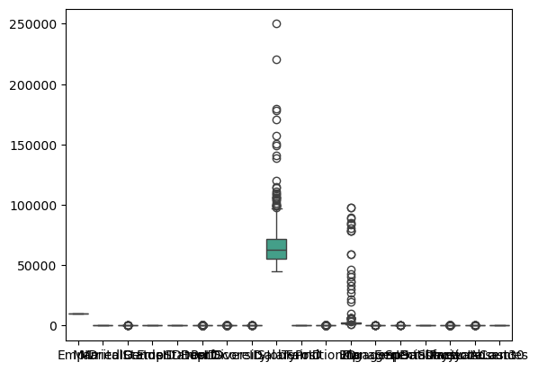

```python
sns.boxplot(df)
```

### 1.1. Un histograma con KDE de los salarios. Analiza la gráfica y responde: ¿Qué rango(s) de salarios son los más populares?

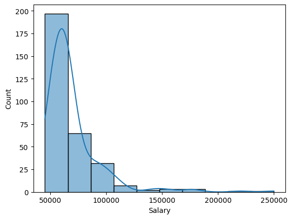

```python
sns.histplot(df, x='Salary', bins=10, kde=True)
```

Los salarios más populares están entre 50,000 y 100,000. La mayoría están entre 50k y 60k.

### 1.2 Un gráfico de violín con los salarios, discriminados por género. Responde ¿Qué grupo tiende a percibir un mayor salario?

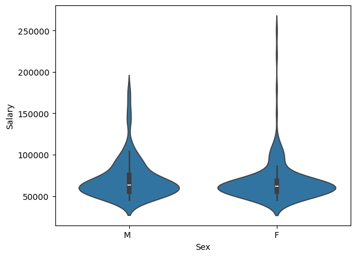

```python
sns.violinplot(data=df, x='Sex', y='Salary')
```

Hay más hombres que mujeres en el rango de entre los 150,000 y 200,000. Aún así hay mujeres que perciben más de 200,000, pero no hay hombres que pasen de los 200,000. En general, hay más hombres que perciben un mayor salario. Pero hay mujeres que lo que nos deja a entender la gráfica es que algunas tienen los puestos más altos o más importantes.

### 1.3. La serie de tiempo (lineplot) correspondiente a la fecha de contratación (DateofHire) con el salario y desagrega por Sex. Responde: ¿en que año se contrataron más mujeres?

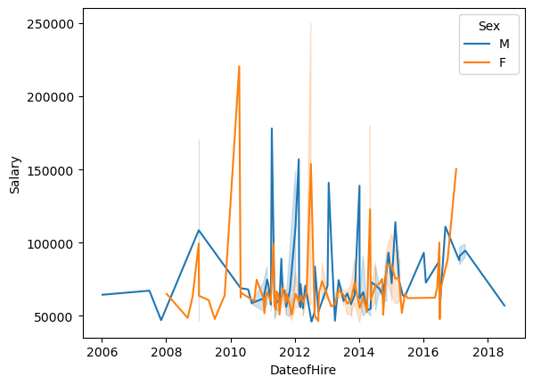

```python
df['DateofHire'] = pd.to_datetime(df['DateofHire'])
sns.lineplot(data=df.sort_values('DateofHire'), x='DateofHire', y='Salary', hue='Sex')
```

### 1.4. Serie de tiempo (con barras) para visualizar la cantidad de contrataciones por año (2008 - 2016) desagregando por Departamento. Considera las dimensiones de la figura para que se aprecie adecuadamente. Agrega título y etiquetas a los ejes. Finalmente analiza la gráfica y responde: ¿en qué año se contrató a más personal de IT/IS?

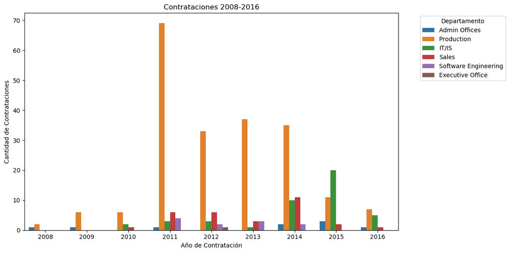

```python
plt.figure(figsize=(12, 6))
sns.barplot(data=hires_by_year_dept, x='YearOfHire', y='Hires', hue='Department')
plt.title('Contrataciones 2008-2016')
plt.xlabel('Año de Contratación')
plt.ylabel('Cantidad de Contrataciones')
plt.legend(title='Departamento', bbox_to_anchor=(1.05, 1), loc='upper left')
plt.tight_layout()
plt.show()
```

El año en el que se contrató más personal de IT/IS fue en el 2015.

## 2. (10 pts) Con el mismo dataframe de salarios, genera una figura con 4 sub gráficos de distinto tipo mostrando diferentes comparativas y desagregando (hue) por alguna variable categórica. Acompaña con un bloque de texto con tu interpretación y justificación para cada subgráfico.

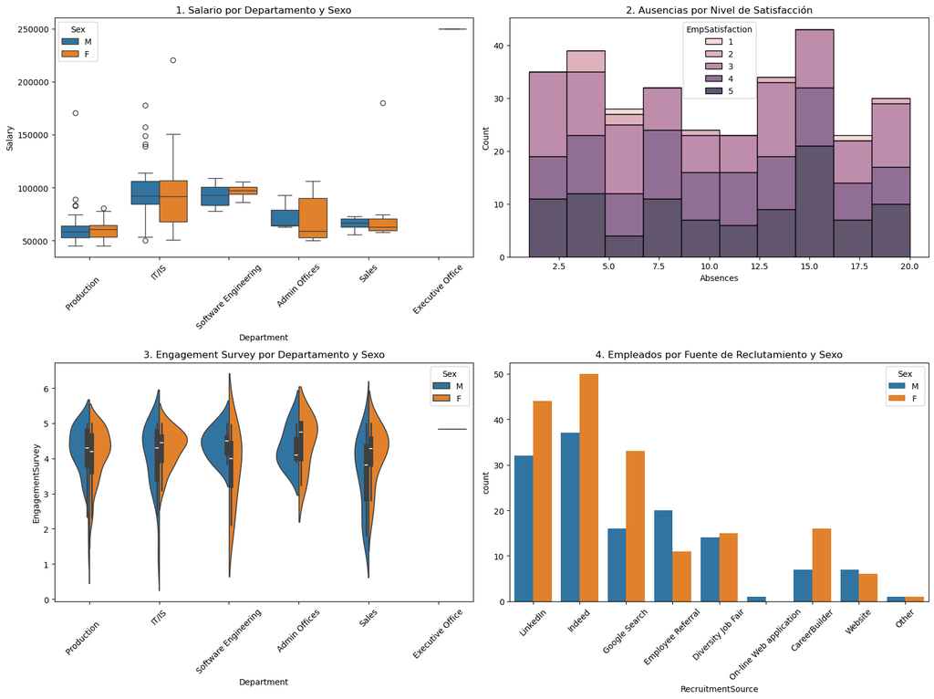

```python
fig, axs = plt.subplots(2, 2, figsize=(16, 12))

# Boxplot de salarios por departamento
sns.boxplot(data=df, x='Department', y='Salary', hue='Sex', ax=axs[0, 0])
axs[0, 0].set_title('1. Salario por Departamento y Sexo')
axs[0, 0].set_xticklabels(axs[0, 0].get_xticklabels(), rotation=45)

# Histograma de ausencias por satisfacción laboral
sns.histplot(data=df, x='Absences', hue='EmpSatisfaction', multiple='stack', bins=10, ax=axs[0, 1])
axs[0, 1].set_title('2. Ausencias por Nivel de Satisfacción')

# Violinplot de EngagementSurvey por Departamento
sns.violinplot(data=df, x='Department', y='EngagementSurvey', hue='Sex', split=True, ax=axs[1, 0])
axs[1, 0].set_title('3. Engagement Survey por Departamento y Sexo')
axs[1, 0].set_xticklabels(axs[1, 0].get_xticklabels(), rotation=45)

# Countplot de empleados por fuente de reclutamiento y sexo
sns.countplot(data=df, x='RecruitmentSource', hue='Sex', ax=axs[1, 1])
axs[1, 1].set_title('4. Empleados por Fuente de Reclutamiento y Sexo')
axs[1, 1].set_xticklabels(axs[1, 1].get_xticklabels(), rotation=45)

plt.tight_layout()
plt.show()
```

## 3. (10 pts) Usando el contexto talk, genera un gráfico de tipo JointPlot usando las variables EmpSatisfaction y Salary donde muestres su recta de regresión. Responde: ¿cómo se interpreta el gráfico?

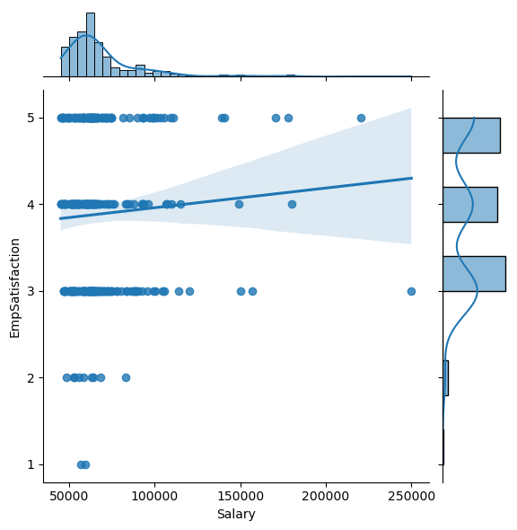

```python
sns.jointplot(x='Salary', y='EmpSatisfaction', data=df, kind='reg')
```

La manera de interpretar el gráfico es fijarse en la línea. Si la línea parece que no tiene dirección o pendiente como en este caso, significa que no hay relación entre las variables.

## 4. (10 pts) Genera el mapa de calor con los coeficientes de correlación y muestra el diagrama de dispersión de puntos de aquel par de variables con coeficiente aproximadamente igual a 0.51 junto con su rugplot.

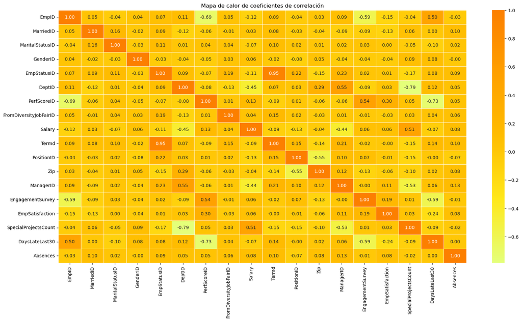

```python
# Mapa de calor de correlaciones
hm = df.corr(numeric_only=True)
plt.figure(figsize=(20,10))
sns.heatmap(hm, annot=True, cmap='Wistia', linewidths=.5, fmt='.2f')
plt.title('Mapa de calor de coeficientes de correlación')
plt.show()
```

- El par que tiene coeficiente de exactamente 0.51 es Special Projects y Salary

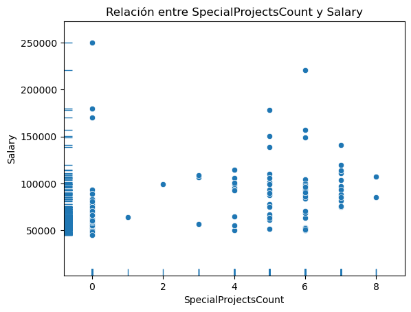

```python
sns.scatterplot(data=df, x='SpecialProjectsCount', y='Salary')
sns.rugplot(data=df, x='SpecialProjectsCount', y='Salary')
plt.xlabel('SpecialProjectsCount')
plt.ylabel('Salary')
plt.title('Relación entre SpecialProjectsCount y Salary')
plt.show()
```

## 5. (10 pts) Realiza una comparativa de salarios a través de diferentes grupos mediante un Faceted histogram. Responde cuál es el género y estado civil con mayor prevalencia de remuneración baja.

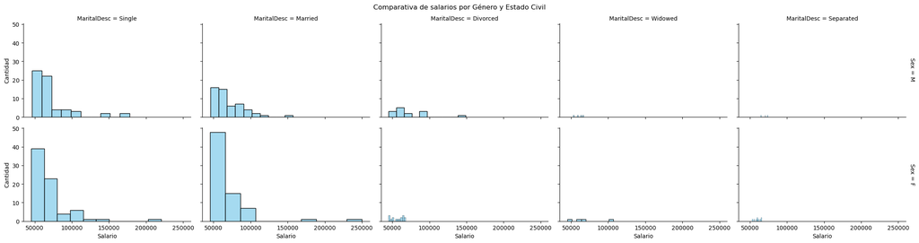

```python
fh = sns.FacetGrid(df, row="Sex", col="MaritalDesc", margin_titles=True, height=3, aspect=1.5)
fh.map(sns.histplot, "Salary", bins=10, color="skyblue")
fh.set_axis_labels("Salario", "Cantidad")
fh.fig.subplots_adjust(top=0.9)
fh.fig.suptitle("Comparativa de salarios por Género y Estado Civil")
plt.show()
```